# NLP with Python Part 2: Sentiment Analysis and Topic Modelling

## Prerequisites

- Basic knowledge of programming and visualizing data with Python, which can be acquired with the [Python Fundamentals](https://info.lse.ac.uk/current-students/digital-skills-lab/python) and [Data Visualization in Python](https://info.lse.ac.uk/current-students/digital-skills-lab/python) series.
- [NLP with Python Part 1: Normalization and Word Frequency](https://mwiemers.github.io/nlp_1.html)
- We will need a working installation of
  - Python and Jupyter notebooks
  - Matplotlib and NLTK
  - Using Anaconda is a simple way to install Python, Jupyter Notebooks and the required libraries on your [Windows](https://repo.anaconda.com/archive/Anaconda3-2020.11-Windows-x86_64.exe) machine or [Mac](https://repo.anaconda.com/archive/Anaconda3-2020.11-MacOSX-x86_64.pkg).
- Gensim (not in Anaconda by default, see how to install below)

## Learning goals

After completing this tutorial you will be able to carry out

- Sentiment analysis with VADER through NLTK
- Topic modelling with LDA through gensim

[figure not shown]

# Sentiment analysis

Sentiment analysis refers to techniques used to assess if a text contains positive or negative affect or attitudes. We will use a sentiment analyser from NLTK called [VADER](https://github.com/cjhutto/vaderSentiment) (Valence Aware Dictionary and sEntiment Reasoner). It is an open source, *rule based* tool "specifically attuned to sentiments expressed in social media".

What *rule* means here is two-fold. Firstly, tokens are annotated with polarity scores. For example, ":)" might add 0.2 to the positive score, and the word "hate" might add 0.4 to the negative score.

Secondly, these additions are conditional on structural information, such as negation or degree modifiers. For example, "not great" would count as something negative and "excellent!" would be more positive than just "excellent".

Of course, these rules will still miss some double meaning, irony or idioms, as language is too complex to classify these through rules. In the appendix, we discuss modern approaches to solving these problems. Nevertheless, lightweight analysers like VADER are sufficient for many applications.

More concretely, suppose we are given a piece of text. This could be any ordered collection of words e.g. multiple sentences associated with some named entity or an extracted topic (we will see details of these later). Here be aware of cleaning the text: we would like to ideally leave the raw version so that we keep information such as uppercase words or punctuation.

### Installing vader

We start by installing the vader library and creating an instance of the Vader sentiment analyzer.

```python
# installing the vader library
from nltk import download
download("vader_lexicon")

# importing the sentiment analyser
from nltk.sentiment import SentimentIntensityAnalyzer

sia = SentimentIntensityAnalyzer()
vader = sia.polarity_scores # Alias the main method for easy access
```

### Getting valence scores

Vader and many other sentiment analysis approaches are based on a semantic lexicon that labels words, smileys etc. according to their affective orientation.

We can check valence of particular tokens through `sia.lexicon`.

```python
print(":)", sia.lexicon[":)"])
print(":(", sia.lexicon[":("])
```

```
:) 2.0
:( -1.9
```

### Analyzing text

Running the Vader sentiment analyzer gives us the compound, positive, neutral and negative score.

The **compound** score is a the sum of words' valence scores adjusted according to rules or heuristics that account for semantic information. Vader uses the heuristics capitalization (e.g. It HURTS), word order, degree modifiers (e.g. It hurts a lot), punctuation amplifiers (e.g. It hurts!), negation (e.g. It doesn't really hurt.), contrasts. The output is normalized to fall between -1 and 1. This is the most useful and most popular metric for measuring overall sentiment of a piece of text.

The compound scores are normalized using the below formula:

$compound = \frac{x}{\sqrt{x^2 + \alpha}}$

- $x$ is the sum of the valence scores for each word, smiley etc. after having adjusted them based on the heuristics
- $\alpha$ is the normalization constant which is set to 15 per default

The **pos**, **neu** and **neg** scores are proportions of text that fall in the respective category, so they add up to 1. These don't take into account any additional rules besides the raw word classification. This is supplementary information, useful for analysing *style* of how the sentiment is conveyed. This information should be avoided for measuring overall sentiment, where the **compound** score is preferred.

Let's compare two sentences. Notice that we always get `neg`+`neu`+`pos`=1.

```python
# Negative sentence
sentence = "i hate this, it's bad and i am angry :/"
print("\""+sentence+"\"")
print("neg", vader(sentence)["neg"])
print("neu", vader(sentence)["neu"])
print("pos", vader(sentence)["pos"])
print("compound", vader(sentence)["compound"])
```

```
"i hate this, it's bad and i am angry :/"
neg 0.763
neu 0.237
pos 0.0
compound -0.9169
```

```python
# Positive sentence
sentence = "i love this! honestly really cool :)"
print("\""+sentence+"\"")
print("neg", vader(sentence)["neg"])
print("neu", vader(sentence)["neu"])
print("pos", vader(sentence)["pos"])
print("compound", vader(sentence)["compound"])
```

```
"i love this! honestly really cool :)"
neg 0.0
neu 0.13
pos 0.87
compound 0.9241
```

As mentioned, this works fine for simple sentences, but it will struggle on more ironic pieces of writing, as here

```python
sentence = "i never saw a better product, if only i could buy more!"
print("\""+sentence+"\"")
print("compound", vader(sentence)["compound"])
```

```
"i never saw a better product, if only i could buy more!"
compound -0.4015
```

```python
sentence = "i never saw a worse product, i wish i didn't get it..."
print("\""+sentence+"\"")
print("compound", vader(sentence)["compound"])
```

```
"i never saw a worse product, i wish i didn't get it..."
compound 0.6433
```

Applications of sentiment analysis with VADER include [hate speech detection](https://arxiv.org/pdf/1703.04009.pdf) and [content recommendations](https://dl.acm.org/doi/10.1145/1651461.1651473). See [Semantic Scholar](https://www.semanticscholar.org/paper/VADER%3A-A-Parsimonious-Rule-Based-Model-for-Analysis-Hutto-Gilbert/bcdc102c04fb0e7d4652e8bcc7edd2983bb9576d?sort=total-citations) for more papers citing VADER. There are many other sentiment analysers. Some simple, like [AFINN](http://www2.imm.dtu.dk/pubdb/pubs/6010-full.html), a list of valence scores per word.

Around 2016, benchmarks were incorporating many rule-based analysers (see [SentiBench](https://arxiv.org/abs/1512.01818)). Due to recent advancements in deep neural network architectures for natural language processing, nowadays benchmarks are usually occupied by fine-tuned models of this kind. For example, see [a recent analysis of contact-tracing reviews](https://arxiv.org/abs/2103.01196).

That said, VADER is often good enough: it's much simpler conceptually, and much cheaper to run. It is also validated by real people in the context of sentiment analysis of social media, so might outperform modern methods in that sense.

# Topic modelling

Topic modelling is an umbrella term for models that extract a set of "topics" from a collection of "documents". A *topic* is a collection of tokens; a pattern of word use, a groups of terms that tend to occur together in documents. A *document* is anything that is a single piece that is also a part of a larger corpora of similar pieces. No semantic information is used at this point: these are statistical models dealing with co-occurence of phrases.

For example, a document can be an article among articles authored by someone, or a chapter among other chapters in a book, or a sentence among sentences attributed to someone. Topic modelling can be applied on anything of this form, but it helps if it makes sense as a collection of documents produced by some entity. Note that multiple documents are necessary: one article won't do, we need either to have a collection of articles, or to instead look at e.g. sentences in that article. Of course, the former is preferred to the latter, as sentences might not contain enough words for the topics to be robustly extracted. Be aware that this will not fail explicitly; the topics will be computed without errors, they just might not be insightful.

One of the most widely used models for topic modelling is the so-called *Latent Dirichlet Allocation (LDA)*. LDA is available to use through many software packages, including `gensim`, our choice for this tutorial. Apart from needing the input as described above (set of text documents), LDA also makes a statistical assumption that *there is a fixed number of topics across documents* and that *each document exhibits the topics to varying degree*. These are of course fairly subjective; we should simply be critical of LDA's output for documents that might not comply with these assumptions. In the earlier example of using sentences as documents, one might argue that many sentences might not exhibit any relevant topics at all.

Suppose we have a corpora of articles about pets, and we run LDA for 4 topics. Slightly changing number of topics should not change prominent topics, but it is hard to predict this in general. We will see later how one could decide on the number of topics to use in a final model. For now, we stick to 4. We inspect computed topics and see

| Topic | Words |
| --- | --- |
| 1 | bark, trained, puppy |
| 2 | meow, whiskers, cat |
| 3 | bird, fly |
| 4 | going, running |

We might suspect that topic 1 captures something about dogs and topic 2 something about cats. Inspection of the weights of each topic within each sentence gives some support for this hypothesis.

| Article about | Topic 1 | Topic 2 | Topic 3 | Topic 4 |
| --- | --- | --- | --- | --- |
| Are cats evil? | 0.2 | **0.6** | 0.1 | 0.1 |
| Caring for cats | 0.1 | **0.7** | 0.2 | 0.0 |
| How many dogs is too many | **0.8** | 0.1 | 0.0 | 0.1 |
| Where to find parrots | 0.3 | 0.1 | **0.5** | 0.1 |

Here is a more graphical characterisation of topic models: documents live on a "probability simplex", which in the case of three topics is a triangle. A hypothetical document located stricly on the red dot would have 100% of the topic 2 and 0% for both topic 1 and 3. This leads to the notion of the "latent space": we can find topic distribution for a new document. If we consider documents indexed by time, we can think of this as *prediction* of the topics in a *future* document.

[figure not shown]

We use the same data on inaugural speeches, as in the previous tutorial. We import some helpers from the `NLTK` and clean the data. Note that this might take some time to download!

```python
from nltk import download
download('inaugural')
download("stopwords")
download('wordnet')
download('punkt')

from nltk import corpus as crp
stopwords = crp.stopwords.words("english")

from nltk import WordNetLemmatizer
lemmatizer = WordNetLemmatizer()

from nltk.corpus import inaugural
```

Recall pre-processing from previous part of this workshop.

```python
# Get the raw speech text data per year
raw_speeches = []
for fileid in inaugural.fileids():
    raw_speeches.append(inaugural.words(fileid))

# Lemmatize every speech and remove stopwords
speeches = []
for speech in raw_speeches:
    inner = []
    for word in speech:
        if word.lower() not in stopwords and word not in ".,;:'’`?!-()" and word != "--":
            inner.append(lemmatizer.lemmatize(word).lower())
    speeches.append(inner)
```

Now, let us process our data so that it can be used to construct a topic model.

```python
from gensim.corpora import Dictionary
from gensim.models import LdaModel
```

`Dictionary` takes a list of documents (a *corpus*) and creates an integer index, that is, assigns an integer to every unique token. We can then access useful representations of our documents through an instance of `Dictionary`

- `doc2idx` converts the document into indices assigned to tokens, the order is preserved
- `doc2bow` converts the document into a so-called ["bag-of-words" (BOW)](https://en.wikipedia.org/wiki/Bag-of-words_model) representation, that is, it only stores number of occurences per token, and order is forgotten

In our case, `speeches` is the corpus and every speech in there is a document. We want to apply `Dictionary` on our corpus and so we run

```python
dct = Dictionary(speeches)
```

Let's also see the two representations we mentioned

```python
# First 5 words from the first speech
print(speeches[0][:5])
```

```
['fellow', 'citizens', 'senate', 'house', 'representatives']
```

```python
# Indices of first 5 words from the first speech
ids = dct.doc2idx(speeches[0][:5])
print(ids)
```

```
[190, 77, 411, 233, 388]
```

```python
# Recover tokens by indices
for i in ids:
    print(dct[i])
```

```
fellow
citizens
senate
house
representatives
```

Now we can use the indices stored with `ids` to create a bag of words for the first 5 words from the first speech.

`doc2bow()` will return the index and the number of occurences for every token from a speech. Below we print the values for the first five words from the first speech. We can see that the occurences are 3, 1, 1, 2 and 2.

```python
# Bag-of-words of first 5 words from the first speech
for i in ids:
    print(dct.doc2bow(speeches[0])[i])
```

```
(190, 3)
(77, 1)
(411, 1)
(233, 2)
(388, 2)
```

We can use `doc2bow()` to create a version of the corpus where instead of raw text, we store bags-of-words. We need this format for our implementation of LDA, `LdaModel`.

```python
bows = []
for speech in speeches:
    bows.append(dct.doc2bow(speech))
```

Now, at last, we create and fit the actual model! We also pass in `dct` as a way to recover tokens from their indices (id to word). Without it, we would see topics as sets of indices!

```python
m = LdaModel(bows, id2word=dct, num_topics=2)
```

Let's inspect the topics, first as strings, and then as nicer plots.

```python
for topic in m.show_topics():
    print("Topic", topic[0], "--->", topic[1])
```

```
Topic 0 ---> 0.009*"people" + 0.007*"government" + 0.007*"u" + 0.007*"nation" + 0.006*"world" + 0.005*"great" + 0.005*"shall" + 0.005*"may" + 0.005*"must" + 0.005*"country"
Topic 1 ---> 0.011*"government" + 0.008*"people" + 0.007*"nation" + 0.006*"upon" + 0.006*"u" + 0.005*"power" + 0.005*"country" + 0.005*"must" + 0.005*"states" + 0.005*"every"
```

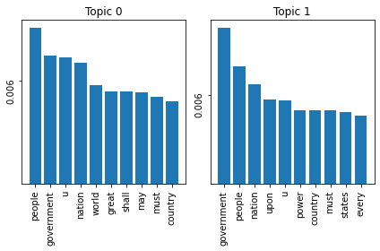

```python
from statistics import mean
from matplotlib import pyplot as plt

def plot_ith_on_ax(i, ax):
    topic = dict(m.show_topic(i))
    ax.bar(topic.keys(), topic.values())
    ax.tick_params(labelrotation=90)
    mid = round(mean(list(topic.values())), 3)
    ax.set_yticks([mid])
    ax.set_title("Topic " + str(i))

fig, axs = plt.subplots(nrows=1, ncols=2)

plot_ith_on_ax(0, axs[0])
plot_ith_on_ax(1, axs[1])

fig.tight_layout()
plt.show()
```

Unfortunately, the topics share top two words and it's not clear how they differ. We will expand on this point later.

Let's see how the topics evolve between years. We will create a heatmap of topics over speeches.

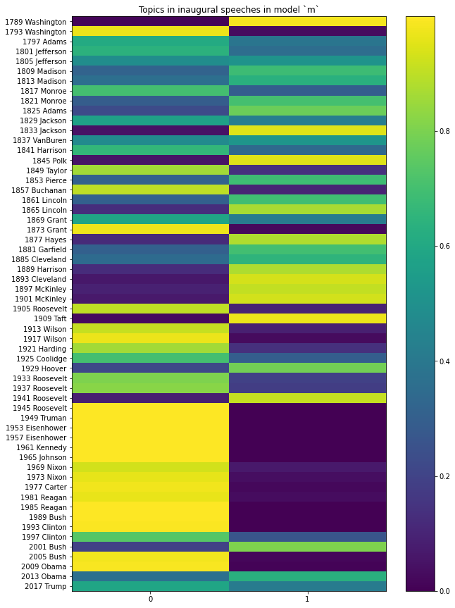

```python
import numpy as np

n_topics = 2

names = []
for fid in inaugural.fileids():
    names.append(fid[0:4] + " " + fid[5:-4])

hm = np.zeros((len(names), n_topics))

for i in range(len(names)):
    topics = dict(m[bows[i]])
    for j in range(n_topics):
        if j in topics.keys():
            hm[i, j] = topics[j]
        else:
            hm[i, j] = 0

fig, ax = plt.subplots()
im = ax.imshow(hm, aspect="auto")
ax.set_xticks(np.arange(n_topics))
ax.set_yticks(np.arange(len(names)))
ax.set_xticklabels(np.arange(n_topics))
ax.set_yticklabels(names)
ax.set_title("Topics in inaugural speeches in model `m`")
fig.set_size_inches(10,15)
plt.colorbar(im)
plt.show()
```

Let's also see where Donald Trump's speech lands on these topics. We can access the topic distribution in a document by indexing the model with the approriate speech in bag-of-words format. We want the last speech, so we want `bows[-1]`.

```python
print(m[bows[-1]])
```

```
[(0, 0.5830159), (1, 0.4169841)]
```

Another nice exercise is to see if we can we guess a document that somehow conform to these topics. To do this, we will need to use the old `Dictionary` instance stored in `dct` to convert text to bag-of-words. Then we can use the model

```python
new_speeches = [
    ["country", "world", "citizen", "nation", "time"],
    ["great", "power", "shall", "upon", "people"]
]

new_bows = [dct.doc2bow(new_speech) for new_speech in new_speeches]
```

```python
print(m[new_bows[0]])
print(m[new_bows[1]])
```

```
[(0, 0.8428414), (1, 0.15715866)]
[(0, 0.82674503), (1, 0.17325497)]
```

## Evaluation and tuning of topic models

We will need two components for this experiment

1. Some (possibly relative) measure of how good the model is given fixed parameters
2. Splititng of the data into training and test: we want to compute the aforementioned measure on data that the model haven't "seen"

Let us first split our corpus into 25% test and 75% train set. We use the sample function to create a list with the indices for the test set. The first argument is the indices to sample from. The second argument is the number of elements to sample from. The double forward slash performs integer division.

```python
from random import sample

# Sample quarter of indices
test_ids = sample(range(len(bows)), len(bows) // 4)

# Create train and test sets
bows_test = []
bows_train = []
for i, bow in enumerate(bows):
    if i in test_ids:
        bows_test.append(bow)
    else:
        bows_train.append(bow)

print("train:", len(bows_train))
print("test:", len(bows_test))
```

```
train: 44
test: 14
```

```python
# 100 topics, 50 iterations
m0 = LdaModel(bows_train, id2word=dct)

# 50 topics, 50 iterations
m1 = LdaModel(bows_train, id2word=dct, num_topics=50)

# 10 topics, 50 iterations
m2 = LdaModel(bows_train, id2word=dct, num_topics=10)

# 5 topics, 50 iterations
m3 = LdaModel(bows_train, id2word=dct, num_topics=5)

# 5 topics, 200 iterations
m4 = LdaModel(bows_train, id2word=dct, num_topics=5, iterations=200)

# 5 topics, 1000 iterations
m5 = LdaModel(bows_train, id2word=dct, num_topics=5, iterations=1000)
```

From the technical perspective, Bayesian framework LDA is written in gives us a straightforward measure called the model evidence, which is the likelihood of the data given the learned model parameters. It is called **perplexity** in the topic modelling context and roughly measures how likely are the documents in test given model trained on documents in train. It was observed that it [ralely correlates with human judgement](http://qpleple.com/perplexity-to-evaluate-topic-models/) on the quality of learned topics. Second option is the so-called **topic coherence**, which aims to use more contextual information than perplexity. See more details [here](http://qpleple.com/topic-coherence-to-evaluate-topic-models/).

Both perplexity and coherence, like $R^2$ in linear models, are useful for relative comparison of models, but discouraged as an objective evaluation of a model. Ideally, we should only compare models with different parameters that are developed on the same data. In practice, topic coherence does provide some qualitative information about how topics are constructed; one can think of it as a measure of the *relative distance between words within a topic*. The closer they are, the more "coherent" the topics should be. Averaging out over topics, we get a single number for a model, and the smaller it is, the better.

`LdaModel` instance has a `log_perplexity` method that takes the hold-out test set from bag-of-words corpus. *The higher the better*.

```python
perplexity_scores = []
for model in [m0, m1, m2, m3, m4, m5]:
    perplexity_scores.append(model.log_perplexity(bows_test))
```

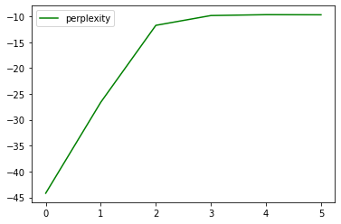

```python
plt.plot(perplexity_scores, label="perplexity", color="green")
plt.legend(loc = 'upper left')
plt.show()
```

We see that fewer topics work better up to model 3. We also see that changing iterations has little effect.

We can get model coherence through `CoherenceModel`. We don't need a train/test split here as we are looking at individual topics extracted from a static corpus and how likely are common words to co-occur in the same document. We focus on the intristic `u_mass` coherence. *In this case, the lower the better*.

We also multiply it by 150 to get them both show up on the same plot (this number is arbitrary).

```python
from gensim.models import CoherenceModel

coherence_scores = []
for model in [m0, m1, m2, m3, m4, m5]:
    coherence_scores.append(CoherenceModel(model=model,
            corpus=bows, coherence='u_mass').get_coherence()*150)
```

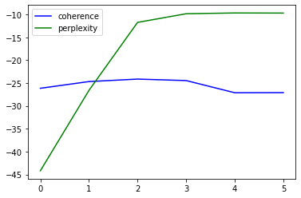

```python
plt.plot(coherence_scores, label="coherence", color="blue")
plt.plot(perplexity_scores, label="perplexity", color="green")
plt.legend(loc="upper left")
plt.show()
```

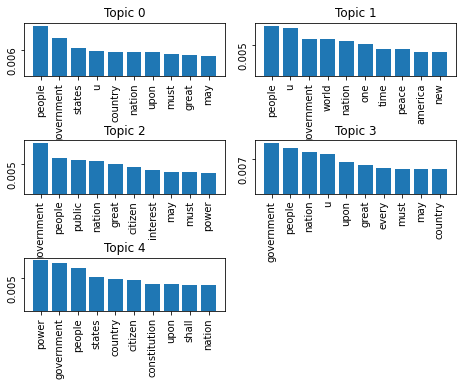

```python
def plot_ith_on_ax(i, ax):
    topic = dict(m4.show_topic(i))
    ax.bar(topic.keys(), topic.values())
    ax.tick_params(labelrotation=90)
    mid = round(mean(list(topic.values())), 3)
    ax.set_yticks([mid])
    ax.set_title("Topic " + str(i))

fig, axs = plt.subplots(nrows=3, ncols=2)

plot_ith_on_ax(0, axs[0, 0])
plot_ith_on_ax(1, axs[0, 1])
plot_ith_on_ax(2, axs[1, 0])
plot_ith_on_ax(3, axs[1, 1])
plot_ith_on_ax(4, axs[2, 0])
axs[2, 1].axis("off")

plt.subplots_adjust(left=0.0,
                    bottom=0.0,
                    right=1.0,
                    top=1.0,
                    wspace=0.15,
                    hspace=1.2)
plt.show()
```

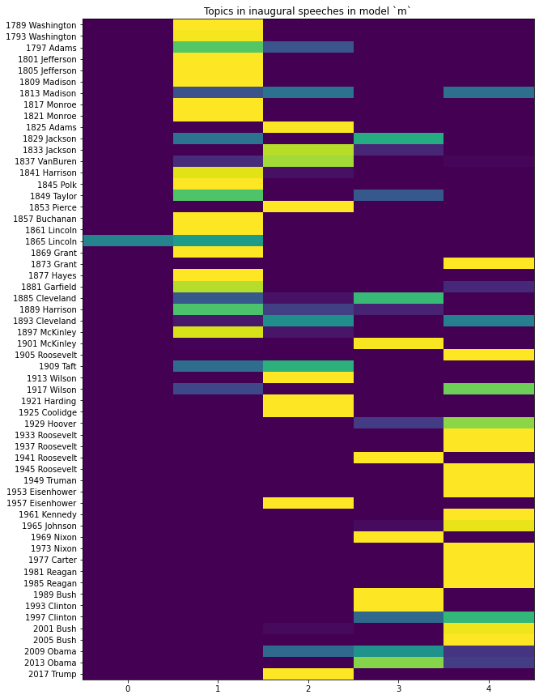

```python
n_topics = 5

m = LdaModel(bows, id2word=dct, num_topics=n_topics, iterations=200)

hm = np.zeros((len(names), n_topics))

for i in range(len(names)):
    topics = dict(m[bows[i]])
    for j in range(n_topics):
        if j in topics.keys():
            hm[i, j] = topics[j]
        else:
            hm[i, j] = 0

fig, ax = plt.subplots()
im = ax.imshow(hm, aspect="auto")
ax.set_xticks(np.arange(n_topics))
ax.set_yticks(np.arange(len(names)))
ax.set_xticklabels(np.arange(n_topics))
ax.set_yticklabels(names)
ax.set_title("Topics in inaugural speeches in model `m`")
fig.set_size_inches(10,15)
plt.show()
```

## What are topics useful for?

### Topics as explanations

Inaugural speech topic modelling example was not very successful, even after tuning. It's a real world data; we didn't have that many examples. One could make an argument that an inaugural speech has too much noise and is written to drive human emotions, and not necessarily communicate information. For these kind of texts, human specialists are still necessary, as in [this](http://inauguratespeeches.com/) analysis from Google News Lab of the same problem.

But of course, sometimes topics are meaningful. Data from social media tends to be especially effective: character limits and large number of examples make the problem much more tractable. One recent study of [Calderón et al. (2020)](https://www.mdpi.com/2076-0760/9/11/188/htm) used LDA to look into hate speech against immigrants on Twitter. In this case, separate topics such as "lack of control of illegal immigration" or "economic assistance to immigrants" were found.

### Topics as features

We saw that we can exprapolate the fitted topic model to predict topics in a new document. Another way to use topics, irrespective whether they were found for a whole corpus or extrapolated to new documents from some existing corpus, is to use them as *features* to other statistical models. For example, suppose we would like to classify tweets as angry or calm. We could represent the tweets with columns such as number of words, sentiment score and the weight of each topic. Logistic regression might be not enough for this problem, but we could choose any other model. Another interesting example is clustering Shakespear using LDA topics in the second part of this [data driven literary analysis](https://codewords.recurse.com/issues/seven/data-driven-literary-analysis).

[Chang et al. (2009)](http://users.umiacs.umd.edu/~jbg/docs/nips2009-rtl.pdf) conducted a large-scale human study on interpretability of topics i.e. how meaningful the latent space is. Suprisingly, good scores of predictive potential (such as perplexity and coherence) were found to be inversely correlated with the semantic potential (how useful are the topics for explanatory analysis). This point should not be taken as a principle against neither use of topic modelling, but rather an encouragement to experiment and not pay too much attention to the scores! Tuning the model might be a good place to start, but shouldn't be a big factor in final modelling decisions.

## Appendix

### More technical details of LDA

LDA is an example of a hierarchical model where static collections of discrete units of data (documents made up of words) are represented as random mixtures over some latent variables (topics) where each such latent variable itself is represented as a distribution over over the units (words). The main innovations of LDA is parametrization that allows for having a document represented by multiple topics a not just one topic (as would be the case in ordinary clustering) and the use of Dirichlet distribution to capture the intuition that a topic should only consist of a relatively small number of words. See the seminal paper [Blei et al. (2003)](https://jmlr.org/papers/volume3/blei03a/blei03a.pdf) for details on applications of LDA. For even more details, see [this website](http://www.cs.columbia.edu/~blei/topicmodeling.html). Note that LDA can be used for any collection of discrete data! In fact, it was originally used in genetics for population modelling. Here is some useful further reading to bridge the gap between formal describtion and applied use

- [Probabilistic Topic Models (2012)](http://www.cs.columbia.edu/~blei/papers/Blei2012.pdf) is a nice semi-technical survey of topic modelling, with a focus on LDA
- [Topic Modelling Made Just Simple Enough (2012)](https://tedunderwood.com/2012/04/07/topic-modeling-made-just-simple-enough/) is a nice introduction non-mathematical to the Bayesian perspective of LDA in the context of digital humanities; the author interprets topic as discourse, and poses that straightforward topics are not necessarily most interesting!
- [Compare and Contrast (2011)](http://sappingattention.blogspot.com/2011/11/compare-and-contrast.html) gives some more perspective on topic modelling for digital humanities

There are also other topic coherence measures, such as `c_v` (for this one, higher the better). The one that we used, the intristic topic coherence `u_mass`, is computed as follows.

1. Fix a topic $T=\{w_1,\ldots,w_N\}$ made of $N$ words
2. $D(w_i)$ the number of documents with word $w_i$ in them
3. $D(w_i, w_j)$ the number of documents with both words $w_i$ and $w_j$
4. Define a score $S(w_i, w_j)=\log \frac{D(w_i, w_j)+1}{D(w_i)}$
5. Coherence of $T$ is then simply $\displaystyle\sum_{i<j} S(w_i, w_j)$

### Newsgroup data

Here is an alternative dataset you can try LDA on. Note that first you need to clean it well!

```python
import gensim.downloader as api
newsgroups = api.load("20-newsgroups")

tpm = []
for i, x in enumerate(newsgroups):
    if x['topic'] == 'talk.politics.misc':
        tpm.append(x['data'])

print(tpm[0])
```

```
From: gsh7w@fermi.clas.Virginia.EDU (Greg Hennessy)
Subject: Re: Why not concentrate on child molesters?
Organization: University of Virginia
Lines: 17

In article <15218@optilink.COM> cramer@optilink.COM (Clayton Cramer) writes:
#Yet, when a law was proposed for Virginia that extended this
#philosophy to cigarette smokers (so that people who smoked away
#from the work couldn't be discriminated against by employers),
#the liberal Gov. Wilder vetoed it.  Which shows that liberals don't
#give a damn about "best person for the job," it's just a power
#play.

Of course Clayton ignores the fact that employers pay health
insurance, and insurance for smokers is more expensive than for
non-smokers.

--
-Greg Hennessy, University of Virginia
 USPS Mail:     Astronomy Department, Charlottesville, VA 22903-2475 USA
 Internet:      gsh7w@virginia.edu
 UUCP:		...!uunet!virginia!gsh7w
```

### Deep Learning and NLP

What we saw so far leaves an impression that quantitative text analysis amounts to either hand-annotated databases driven by linguistic theory (such as WordNet) or extracting information from phrase occurence patterns with statistics. The former is not only expensive to maintain, but also does not offer much insight beyond well-behaved contexts. The latter makes no use of the rich context and semantics, and so will miss out on the likes of irony, double meaning or idioms. But as mentioned in the section on sentiment analysis, best results are obtained using an entirely different methodology.

Neural network is a high-dimensional (many more parameters than e.g. linear regression) model that can be made arbitrarily complex (*deep*). It represents some function of the data and is *trained* on annotated examples so that this function maps to the right labels. They are much more expensive to compute than simpler models like linear regression, but are far superior in generalizing to unseen data points. A significant realization was that we can use these models to force our data into some lower-dimensional representation and work with that, often with more deep neural networks. With text, it works roughly as follows

- Enumerate unique tokens and index them by 1, 2, 3, ... (as with processing for topic modelling)
- Assign to each token a vector with 1 on the index of that token in the dictionary and 0 otherwise
- Compress these to real-valued vectors in a lower-dimensional space, e.g. 200 dimensions
  - Recall that in a vector space gives a notion of closeness (with respect to a norm)
  - Create buckets of words close to each other, and set the network so that they are "close" in the target vector space
  - We might see that things like `king` + `woman` = `queen` happen; we extracted some contextual information!
  - Word2vec was the first model of this, now there are many more
- Build another deep model, this time using the dense vector representation as input

Another big revolution in NLP were a kind of deep neural models called *transformers*, introduced by the 2017 paper [Attention is All You Need](https://arxiv.org/abs/1706.03762). Next major discovery was that [language models are few-shot learners](https://arxiv.org/abs/2005.14165v1), which means that we can compute these huge transformer-based models on some large text datasets, and then reuse them in new contexts by giving them a small number of examples from the new context (also known as *fine-tuning*).

These models are decent even without fine-tuning. We call these tasks zero-shot, as there are no new context-specific examples we show to the model. We will focus on zero-shot classification. We provide some labels, like `vacation`, `work`, `school`, and text will be assigned confidence level for each label. There is a nice package with many recent language models, called `transformers`. You need to install it manually, along with `torch`.

```python
!pip install --user torch transformers
import torch
from transformers import pipeline
```

More concretely, we load the Facebook's [BART](https://arxiv.org/abs/1910.13461) model trained on [Multi-Genre Natural Language Inference (MultiNLI)](https://cims.nyu.edu/~sbowman/multinli/) dataset. NLI models assign to a pair of sentences a label: *entails*, *contradict* or *neutral*. It is then adapted for zero-shot classification task by adding a sentence "This text is about LABEL" to make a pair with an input sentence. The relation between the two sentences is then posed by BART, and the confidence translates to classification confidence for a given label.

```python
bart_mnli = pipeline("zero-shot-classification", model="facebook/bart-large-mnli")
```

We can now construct an ad hoc sentiment analysis solution by setting labels to "good" and "bad".

```python
sentence = "kinda not great i guess"
labels = ["good", "bad"]
print(bart_mnli(sentence, labels))
print(vader(sentence))
```

```
{'sequence': 'kinda not great i guess', 'labels': ['bad', 'good'], 'scores': [0.9427629709243774, 0.057236962020397186]}
{'neg': 0.501, 'neu': 0.499, 'pos': 0.0, 'compound': -0.4617}
```

[Here](https://skimai.com/fine-tuning-bert-for-sentiment-analysis/) is a challenging example of fine-tuning one such model for the purpose of sentiment analysis.